# STAT 480 Homework 9

Chenz Zhang, NetID chenziz2

4/21/2019

`Code reference: Original examples written by James Balamuta for University of Illinois Stat 430: Big Data Analysis Foundations in April 2015. Additional comment modifications also made by Darren Glosemeyer in April for Stat 480 offering at the University of Illinois. Code is modified by Chenzi Zhang in April 21, 2019 for Stat 480 homework9 at the University of Illinois.`

Before running my code, please change path to the correct directory.

# Exercise 1

## 1. Investment by firm over time

**Investment by firm over time**

[interactive chart not shown]

### Interpret

This plot tells us about changes in investment over the time frame of the data. y-axis represents the magnitude of investment. x-axis represnets year variable. By changing the number of firm below the graph, the data of that firm will be shown in the graph with the brightest color.

### Overall

The overall trend for investment magnitudes is increasing when year is increasing. In 1940s, the total investment is just higher than 1000. However, in 1953, the total investment is higher than 2700.

### Between firms

In general, the magnitudes of investment for firm1 and firm2 are the highest among these 10 firms. On the contrary, firm10 has the lowest investment which is not above 10.

There are two major shrinkages for all firms just before year 1940 and year 1950.

Firm4 ~ firm10 have relatively flat values over time because their graph width is nearly flat.

Firm1 ~ firm 3 have relatively larger increase or derease. Firm1 has much larger investment in the end of the whole period than at the beginning of this period. Firm2 has three major decreases in year 1939, year 1945, year 1954 and three major increase in year 1940, year 1946, year 1949 ~ year 1952. Firm3 has two major decreases in year 1938, year 1944, and two major increases after the decreases.

## 2. Value by firm over time

**Value by firm over time**

[interactive chart not shown]

### Interpret

This plot tells us about changes in value over the time frame of the data. y-axis represents the magnitude of value. x-axis represnets year variable. By changing the number of firm below the graph, the data of that firm will be shown in the graph with the brightest color.

### Overall

The overall trend for value is almost at the same level with some varies when year is increasing. In year 1937 and year 1953, year 1954, it has roughly the highest value. At the beginning of this period, overall value is the lowest.

### Between firms

In general, the magnitudes of investment for firm1 is the highest among these 10 firms. On the contrary, firm10 has the lowest investment which is not above 90.

There are two major shrinkages for all firms just in year 1937 and year 1942.

Firm4 ~ firm10 have relatively flat values over time because their graph width is nearly flat.

Firm1 ~ firm 3 have relatively larger increase or derease. Firm1 has much larger investment in the end of the whole period than at the beginning of this period. It has four major increases in year 1937, year 1939, year 1946, year 1953 and three major decreases in year 1938, year 1942, year 1947. Firm2 and firm3 has two major decreases in year 1938, year 1948, and a major increase in year 1937.

## 3. Capital by firm over time

**Capital by firm over time**

[interactive chart not shown]

### Interpret

This plot tells us about changes in capital over the time frame of the data. y-axis represents the magnitude of investment. x-axis represnets year variable. By changing the number of firm below the graph, the data of that firm will be shown in the graph with the brightest color.

### Overall

The overall trend for capital is obvious increasing when year is increasing. The magnitude of capital at the end of this period is almost 9 times larger than the magnitude of capital at the beginning of this period.

### Between firms

In general, the magnitudes of investment for firm1 and firm2 are the highest among these 10 firms. On the contrary, firm10 has the lowest investment which is not above 10.

There are two sharp incearse for all firms just before year 1946 and year 1937.

Firm9 have relatively flat values over time because its graph width increases slightly.

Firm1 has relatively larger increase. It has much larger investment in the end of the whole period than at the beginning of this period. Firm2 has a relatively larger decrease in year 1946 becasue its graph width at this point shrinks sharply.

# Exercise 2

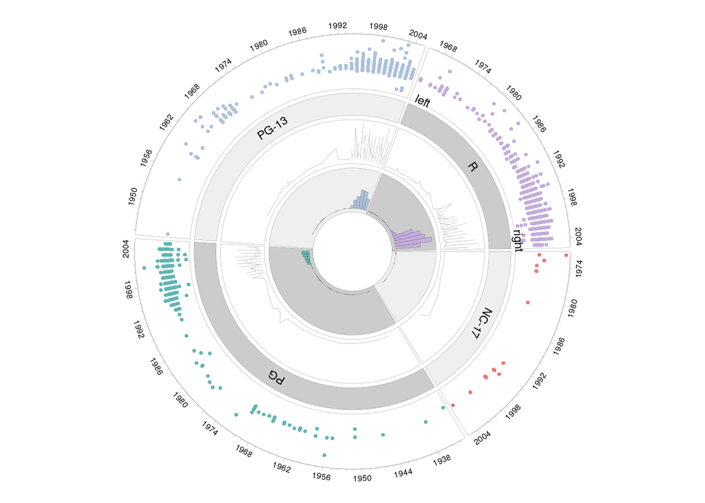

## Movie length

In general, with year increasing, the range or deviation of movie length tends to be larger. Longest PG-13 movies appear during 1998 to 2004, this kind of movie tends to has longer record appear when year increase.

On the contrary, NC-17 movies tends to have the flattest movie length just except one point before year 1974. For PG and R movies, shortest movies appear when year increases, especially during 1998 to 2004.

## Budget

For PG, PG, R, largest budget is concentrated in the period from 1992 to 2005. The largest budget for NC-17 is concentrated in the year 1998. In addition, there is small peak for PG in year 1980 and there also a small peak for PG-13 in 1990. It seems big productions flocking after 1990s.

## Number of movies

Overall, large number of movies appear after 1992. During this period, R movies has the largest number. PG-13 has the second largest number. PG follows that. NC-17 always has the smallest number of movies.

Trend: R and PG-13 both has a decrease after the peak in 2000. PG has constantly increasing number of movies. NC-17 is still flat.

Therefore, R, PG-13, PG have relatively similar trend, only NC-17 is different.

# Exercise 3

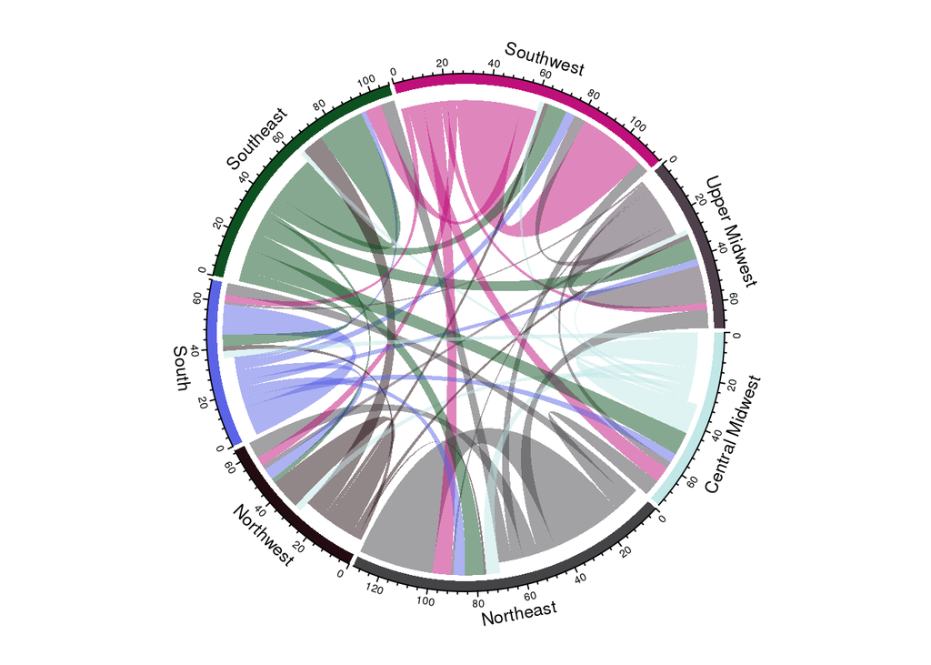

This is a chord diagram showing the migration amount/number.

## Migration numbers out of region

Based on the out of region migration from chord diagram, I see Southeast has highest migration number and Upper Midwest have lowest migration number. The order for migration number from large to low: Southeast, Northeast, Southwest, South, Central Midwest, Northwest, Upper Midwest.

## Out-of-region migration paths

The most common out of region migration path is `Southeast to Central Midwest`. There are two zero number (least common) from `Upper Midwest to Southeast` and from `Northwest to Central Midwest`. In addition, `Southeast to Upper Midwest` and `Northwest to Southeast` are popular paths.

# Exercise 4

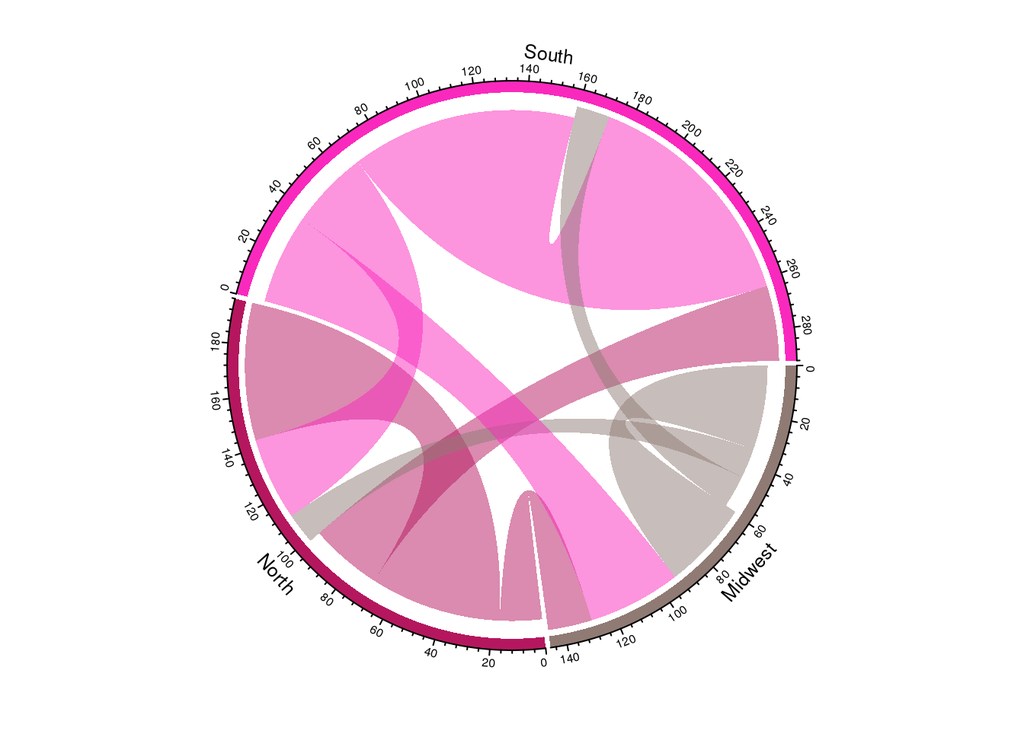

This is a chord diagram showing the migration amount/number.

## Migration numbers out of region

Based on the out of region migration from chord diagram, I see South has highest migration number and Midwest has lowest migration number. The order for migration number from large to low: South, North, Midwest.

## Out-of-region migration paths

The most common out of region migration path is `South to Midwest`. The least common path is from `Midwest to North`. In addition, `South to Midwest` and `South to North` are popular paths.